# MI&ZI_2022/23

Kristo Palic

2023-01-31

## OSNOVE STATISTIČKOG PROGRAMIRANJA

#### **Fakultet elektrotehnike i računarstva, Sveučilište u Zagrebu**

#### 24/11/2022

# **MEĐUISPIT**

======================================================================================

#### JMBAG: 0246074767

#### Ime i prezime: Kristo Palić

#### e-mail: kp024607476@fer.hr

#### IP adresa: 86.33.75.184

======================================================================================

#### OSNOVNE UPUTE

U nastavku slijedi niz zadataka za završni ispit. Rješenja zadatka mogu uključivati **upisivanje programskog koda** ili **čistog teksta** te **izvršavanje programskog koda**. Molimo da se pridržavate sljedećih naputaka:

- prije rješavanja stisnite gumb **Knit to HTML** kako bi provjerili ispravnost sučelja te dobili predložak ispita u preglednijem obliku u prozoru preglednika s desne strane
- ukoliko nije drugačije navedeno, prostor za rješavanje zadataka sami stvarate kombinacijom tipaka **CTRL+ALT+I** ili odabirom opcija **Insert -> R**
- pažljivo čitajte tekstove zadataka
- tekst zadatka može sadržavati i programski kod kojeg morate izmijeniti i nadopuniti te izvršiti već prema uputama danim u tekstu zadatka i / ili komentarima postojećeg programskog koda
- ukoliko je rješenje zadatka programski kod koji nešto ispisuje, budite sigurni da bilježnica uključuje i taj ispis
- programski kod slobodno komentirajte

Nakon ispunjavanja bilježnice odaberite opciju **Knit to HTML* i pohranite rezultat u HTML obliku u predviđeni repozitorij na *Moodle* stranicama predmeta.

Pohranom HTML bilježnice pod Vašim korisničkim imenom i lozinkom garantirate da tijekom ove provjere znanje niste od drugoga primili niti pružili pomoć te da se niste koristili nedopuštenim sredstvima. Ove su radnje povreda Kodeksa ponašanja te mogu uzrokovati trajno isključenje s Fakulteta.

Prije rješavanja zadataka postavite datoteku `MI_predlozak_podaci.rda` u mapu gdje se nalazi ova bilježnica i učitajte podatke iz nje uz pomoć sljedeće naredbe:

```r
rm(list = ls())    # brišemo postojeće varijable kako bi krenuli od nule
load("./MI/MI_podaci.rda")
```

Učitane podatke možete vidjeti u prozoru s gornje desne strane sučelja **RStudio**, tab *Environment**.

======================================================================================

## ZADATCI

**NAPOMENA** U zadacima nije dopušteno koristiti eksplicitne programske petlje!

### 1. **(1 + 1 bod)**

Stvorite sljedeće numeričke vektore:

- vektor `a`: (-1000, -990, -980, …., -10, 0)

```r
vecA <- seq(-1000, 0, 10)
```

- vektor `b`: (1, -1, 2, -2, …, 99, -99, 100, -100)

```r
# vektor 1:100 s ponavljanjem svakog clana
vecB <- rep(1:100, each = 2)
# vektor s ponovljenim čanovima pomnožen s vektorom (1, -1, ... 1, -1)
vecB <-  vecB * rep(c(1, -1), 100)
```

Ispišite na zaslon **prvih 10 elemenata vektora `a`** i **zadnjih 10 elemenata vektora `b`**.

### Rješenje

```r
#a)
head(vecA, 10)
#vecA[1:10]

#b)
tail(vecB, 10)
#vecB[(length(vecB) - 9):length(vecB)]
```

```
##  [1] -1000  -990  -980  -970  -960  -950  -940  -930  -920  -910
##  [1]   96  -96   97  -97   98  -98   99  -99  100 -100
```

### 2. **(1 + 1 bod)**

1. Pronađite i ispišite najveći element matrice `m`. Ispišite koliko puta se pojavljuje u matrici.

### Rješenje

```r
max(m)
sum(m == max(m))
```

```
## [1] 10
## [1] 99
```

### Rješenje

```r
m[apply(m, 1, sum) > 70,]
```

```
##      [,1] [,2] [,3] [,4] [,5] [,6] [,7] [,8] [,9] [,10]
## [1,]    5    9    6    5    6    7   10    9   10     4
## [2,]   10    8    8    9    4    9    3   10    8     6
## [3,]    9    9    8    6    3    9    8    3   10     9
```

### 3. **(1 + 1 bod)**

Stvorite listu `l` uz pomoć sljedeće naredbe:

```r
l<- list(a = 1:5, b = seq(2, 20, 4), c("2", "4", "6", "8", "10", "12"))
l
```

```
## $a
## [1] 1 2 3 4 5
##
## $b
## [1]  2  6 10 14 18
##
## [[3]]
## [1] "2"  "4"  "6"  "8"  "10" "12"
```

1. pretvorite treći element liste u numerički tip i preimenujte ga u `"c"`. Ispišite listu.

### Rješenje

```r
l[[3]] <- as.numeric(l[[3]])
names(l)[3] <- "c"
l
```

```
## $a
## [1] 1 2 3 4 5
##
## $b
## [1]  2  6 10 14 18
##
## $c
## [1]  2  4  6  8 10 12
```

2. Odgovorite: može li se gornja lista pretvoriti u podatkovni okvir? Ako da, obavite pretvorbu i ispišite novi podatkovni okvir. Ako ne, odsječak ostavite prazan i ispod odsječka obrazložite zašto pretvorba nije moguća.

### Rješenje

OBJAŠNJENJE: Ne jer elementi nemaju isti broj elemenata

### 4. **(1 + 1 bod)**

U konzoli proučite sadržaj znakovnog vektora `t`. U prostoru za rješenje pretvorite ga u ordinalni faktor `t.f` te potom ispišite frekvencije pojedinih kategorija.

### Rješenje

```r
t.f <- factor(t, levels = c("vrlo hladno", "hladno", "umjereno", "toplo", "vrlo toplo"), ordered = TRUE)
table(t.f)
```

```
## t.f
## vrlo hladno      hladno    umjereno       toplo  vrlo toplo
##           5          15          25          20           5
```

### 5. **(0.5 + 0.5 bod)**

Proučite objekt `points`.

1. O kojem se objektnom tipu radi (S3, S4, RC)? U programski odsječak ispišite naredbe kojima to možete otkriti, a ispod odsječka napišite rješenje.

### Rješenje

```r
otype(points)
```

```
## [1] "S4"
```

OBJAŠNJENJE: Radi se o objektnom tipu S4.

2. Ispišite prosjek točaka pohranjenih u elementu naziva `"x3"` objekta `points`.

### Rješenje

```r
mean(points@x3)
```

```
## [1] 15.03891
```

### 6. **(2 boda)**

Napravite funkciju `createExperimentMatrix(n, k)` koja za zadane cijele brojeve `n` i `k` vraća matricu dimenzija `n x k+1` u kojoj se u prvom stupcu nalaze indeksi redaka a ostatak matrice je popunjen nulama. Na primjer, za vrijednost parametra `n` i `k` jednaku `4` funkcija mora vratiti matricu koja izgleda ovako:

```
1 0 0 0 0
2 0 0 0 0
3 0 0 0 0
4 0 0 0 0
```

Argumenti `n` i `k` moraju biti numerički, strogo veći od 1 i strogo manji od 1001. Ukoliko je funkcija primila neispravne argumente treba prestati s radom i izbaciti grešku. Ako primljeni numerički argumenti imaju decimalni dio za stvaranje matrice treba gledati samo dio ispred decimalne točke.

### Rješenje

```r
createExperimentMatrix<- function(n, k) {
  stopifnot(is.numeric(n) && is.numeric(k))
  stopifnot(n > 1 && n < 1001 && k > 1 && k < 1001)

  cbind(1:n, matrix(0, nrow = n, ncol = k))
}

createExperimentMatrix(4,2)
```

```
##      [,1] [,2] [,3]
## [1,]    1    0    0
## [2,]    2    0    0
## [3,]    3    0    0
## [4,]    4    0    0
```

### 7. **(0.5 + 1.5 boda)**

U konzoli proučite podatkovni okvir `earthquakes`.

1. Ispišite podatke o svim potresima jačim od 8 po Richteru.

### Rješenje

```r
head(earthquakes)

earthquakes %>%
  filter(richter > 8)
```

```
## # A tibble: 6 × 7
##    year month      day richter area                        region    deaths
##   <dbl> <chr>    <dbl>   <dbl> <chr>                       <chr>      <dbl>
## 1  1902 April       19     7.5 Quezaltenango and San Marco Guatemala   2000
## 2  1902 December    16     6.4 Uzbekistan                  Russia      4700
## 3  1903 April       28     7   Malazgirt                   Turkey      3500
## 4  1903 May         28     5.8 Gole                        Turkey      1000
## 5  1905 April        4     7.5 Kangra                      India      19000
## 6  1906 January     31     8.8 Esmeraldas (off coast)      Ecuador     1000
## # A tibble: 9 × 7
##    year month      day richter area                   region        deaths
##   <dbl> <chr>    <dbl>   <dbl> <chr>                  <chr>          <dbl>
## 1  1906 January     31     8.8 Esmeraldas (off coast) Ecuador         1000
## 2  1906 August      17     8.6 Valparaiso             Chile           3882
## 3  1907 October     21     8.1 Central                Asia           12000
## 4  1933 March        2     8.4 Sanriku                Japan           2990
## 5  1934 January     15     8.1 Bihar                  India-Nepal    10700
## 6  1946 December    29     8.1 Honshu                 Japan           1362
## 7  1950 August      15     8.6 Assam                  India           1526
## 8  1960 May         21     9.5 South                  Chile           1655
## 9  1964 March       27     9.2 Alaska                 United States    131
```

2. Za sve potrese koji su se dogodili u proljetnim mjesecima (ožujak, travanj, svibanj) u turskoj regiji (regija “Turkey”) s poznatim brojem žrtava ispišite godinu, mjesec i broj stupnjeva po richteru.

### Rješenje

```r
earthquakes %>%
  filter(month %in% c("March", "April", "May")) %>%
  filter(region == "Turkey") %>%
  filter(!is.na(deaths)) %>%
  select(year, month, richter)
```

```
## # A tibble: 7 × 3
##    year month richter
##   <dbl> <chr>   <dbl>
## 1  1903 April     7
## 2  1903 May       5.8
## 3  1946 May       5.9
## 4  1953 March     7.3
## 5  1970 March     6.9
## 6  1971 May       6.9
## 7  1992 March     6.8
```

### 8. **(0.5 + 1.5 bod)**

Učitajte podatke iz datoteke `worldPhones.csv` u varijablu `worldPhones`. U konzoli proučite okvir `worldPhones`.

1. Odgovorite: radi li se o urednim podacima? Zašto?

### Rješenje

```r
worldPhones <- read.csv("./MI/worldPhones.csv")
head(worldPhones)
```

```
##   Year N.Amer Europe Asia S.Amer Oceania Africa Mid.Amer
## 1 1951  45939  21574 2876   1815    1646     89      555
## 2 1956  60423  29990 4708   2568    2366   1411      733
## 3 1957  64721  32510 5230   2695    2526   1546      773
## 4 1958  68484  35218 6662   2845    2691   1663      836
## 5 1959  71799  37598 6856   3000    2868   1769      911
## 6 1960  76036  40341 8220   3145    3054   1905     1008
```

OBJAŠNJENJE: Ne. Vrijednosti kategorijskog stupca nalaze se razbacane po stupcima.

2. Izmjenite podatkovni okvir `worldPhones` tako da ima stupce `Year`, `WorldRegion` i `NumberOfPhones`. Ispišite podskup podataka konačnog podatkovnog okvira koji se odnosi na godine 1956, 1957 i 1958.

### Rješenje

```r
library(tidyr)
worldPhones <- pivot_longer(worldPhones, cols = N.Amer:Mid.Amer,
                            names_to = "WorldRegion",
                            values_to = "NumberOfPhones")
worldPhones[worldPhones$Year %in% c(1956, 1957, 1958),]
```

```
## # A tibble: 21 × 3
##     Year WorldRegion NumberOfPhones
##    <int> <chr>                <dbl>
##  1  1956 N.Amer               60423
##  2  1956 Europe               29990
##  3  1956 Asia                  4708
##  4  1956 S.Amer                2568
##  5  1956 Oceania               2366
##  6  1956 Africa                1411
##  7  1956 Mid.Amer               733
##  8  1957 N.Amer               64721
##  9  1957 Europe               32510
## 10  1957 Asia                  5230
## # … with 11 more rows
```

## OSNOVE STATISTIČKOG PROGRAMIRANJA

#### **Fakultet elektrotehnike i računarstva, Sveučilište u Zagrebu**

#### 26/01/2023

# **ZAVRŠNI ISPIT**

======================================================================================

#### JMBAG: 0246074767

#### Ime i prezime: Kristo Palić

#### e-mail: kp024607476@fer.hr

#### IP adresa: 86.33.75.184

======================================================================================

Učitane podatke možete vidjeti u prozoru s gornje desne strane sučelja **RStudio**, tab *Environment**.

======================================================================================

## ZADACI

**NAPOMENA** U zadacima nije dopušteno koristiti eksplicitne programske petlje!

## 1. ZADATAK (8 bodova)

Za podatke iz podatkovnog okvira ispišite sljedeće:

**(2 boda)**

1. Za prvih 10 pjesama čiji je naziv kraći od 8 znakova ispišite naziv umjetnika i naziv pjesme.

**RJEŠENJE:**

```r
music %>%
  filter(nchar(song.title) < 8) %>%
  select(artist.name, song.title) %>%
  head(10)
  #slice(1:10)
```

```
##                   artist.name song.title
## 1               Suzanne Ciani     Stream
## 2             Nine Inch Nails      Metal
## 3            The Dirty Skirts       Wake
## 4                 Kai Winding     Mangos
## 5  Vince Guaraldi / Bola Sete      Choro
## 6         Organized Konfusion       Hate
## 7              Porcupine Tree    Waiting
## 8                  Gil Semedo      Festa
## 9               Suzanne Ciani     Mozart
## 10                 The B-52's        Wig
```

**(2 boda)** b) Za sve pjesme čiji naziv sadrži niz slova “cool” ili “hot” (neovisno o veličini slova) a koje imaju poznatu godinu izlaska ispišite naziv umjetnika, naziv pjesme, godinu izdavanja i popularnost. Ispis poredajte po godini izdavanja uzlazno.

**RJEŠENJE:**

```r
library(stringr)
music %>%
  filter(str_detect(tolower(song.title), "(hot|cool)")) %>%
  filter(year > 0) %>%
  filter(!is.na(year)) %>%
  select(artist.name, song.title, year, song.hotness) %>%
  arrange(year)
```

```
##             artist.name                          song.title year song.hotness
## 1      Buckwheat Zydeco                     Hot Tamale Baby 1987    0.4961753
## 2       Charlie Peacock                  Hot Night Downtown 1988    0.2884816
## 3   Asleep At The Wheel                     Hot Rod Lincoln 1988    0.5493958
## 4             Cocoa Tea                         Cooling Out 1992    0.0000000
## 5            Helen Love                              So Hot 1994    0.2998775
## 6     Zbigniew Preisner                Morning at the hotel 1994    0.4370362
## 7            Diesel Boy                     Cooler Than You 1998    0.4056522
## 8   James Newton Howard                         Photographs 1999    0.4330051
## 9         Basement Jaxx                            La Photo 1999    0.3603706
## 10         Erick Sermon                             I'm Hot 2001    0.4509923
## 11             Steinski        Hot Spot (Terrible Love Mix) 2003    0.4330051
## 12           Williamson           Cool People Make Me Tired 2005    0.3712084
## 13 The Notorious B.I.G. Who Shot Ya (Amended Album Version) 2007    0.2742817
## 14          Soul Ballet                       the Cool Down 2007    0.5692757
## 15          Webb Wilder                   Too Cool for Love 2009    0.2452843
```

**(2 boda)** c) Za nasumičnih 10 pjesama iz žanra `"blues-rock"` ispišite naziv umjetnika, naziv albuma, naziv pjesme i trajanje u minutama i sekundama (npr. 193 = “3m 13s”)

**RJEŠENJE:**

```r
set.seed(1281)

music %>%
  filter(genre == "blues-rock") %>%
  slice_sample(n = 10) %>%
  transmute(artist.name, release.name, song.title,
            durationMin = str_c(duration %/% 60, " min ", duration %% 60, " sek"))
```

```
##                       artist.name                 release.name
## 1       The Fabulous Thunderbirds Hot Stuff: The Greatest Hits
## 2                    Leon Russell                       Carney
## 3                 Deborah Coleman           Soft Place To Fall
## 4                The Gone Jackals                 Faith Healer
## 5                    Janis Joplin                        Janis
## 6  Smokin' Joe Kubek & Bnois King           Roadhouse Research
## 7                     Bad Company             Fame And Fortune
## 8                     Bad Company             Straight Shooter
## 9                    Eddie Turner                         Rise
## 10      The Fabulous Thunderbirds               Powerful Stuff
##                       song.title  durationMin
## 1                     Why Get Up 3 min 50 sek
## 2                   Roller Derby 2 min 26 sek
## 3                       Confused 3 min 29 sek
## 4  Faith Healer (Digital Single)  4 min 8 sek
## 5                          Maybe  4 min 7 sek
## 6                    Tell Me Why 3 min 41 sek
## 7           Valerie (LP Version) 3 min 29 sek
## 8                     Call On Me  6 min 5 sek
## 9                           Rise  5 min 7 sek
## 10           Rainin' In My Heart 3 min 41 sek
```

**(2 boda)** d) Ispišite prosječno trajanje i popularnost pjesama izdanih u ’80-tima, za svaku godinu iz tog perioda.

**RJEŠENJE:**

```r
music %>%
  filter(year >= 1980,year <= 1989) %>%
  group_by(year) %>%
  summarise(avgDuration = mean(duration), avgHotness = mean(song.hotness))
```

```
## # A tibble: 10 × 3
##     year avgDuration avgHotness
##    <int>       <dbl>      <dbl>
##  1  1980        218.      0.514
##  2  1981        215.      0.496
##  3  1982        256.      0.421
##  4  1983        230.      0.437
##  5  1984        234.      0.430
##  6  1985        232.      0.475
##  7  1986        233.      0.457
##  8  1987        239.      0.491
##  9  1988        221.      0.472
## 10  1989        255.      0.428
```

## 2. ZADATAK (6 bodova)

Datoteke `graph1.png`, `graph2.png` i `graph3.png` sadrže tri vizualizacije podataka iz okvira `music` (ili nekog njegovog podskupa). Pokušajte rekonstruirati ove vizualicije.

**(2 boda)** a) `graph1.png`

**RJEŠENJE:**

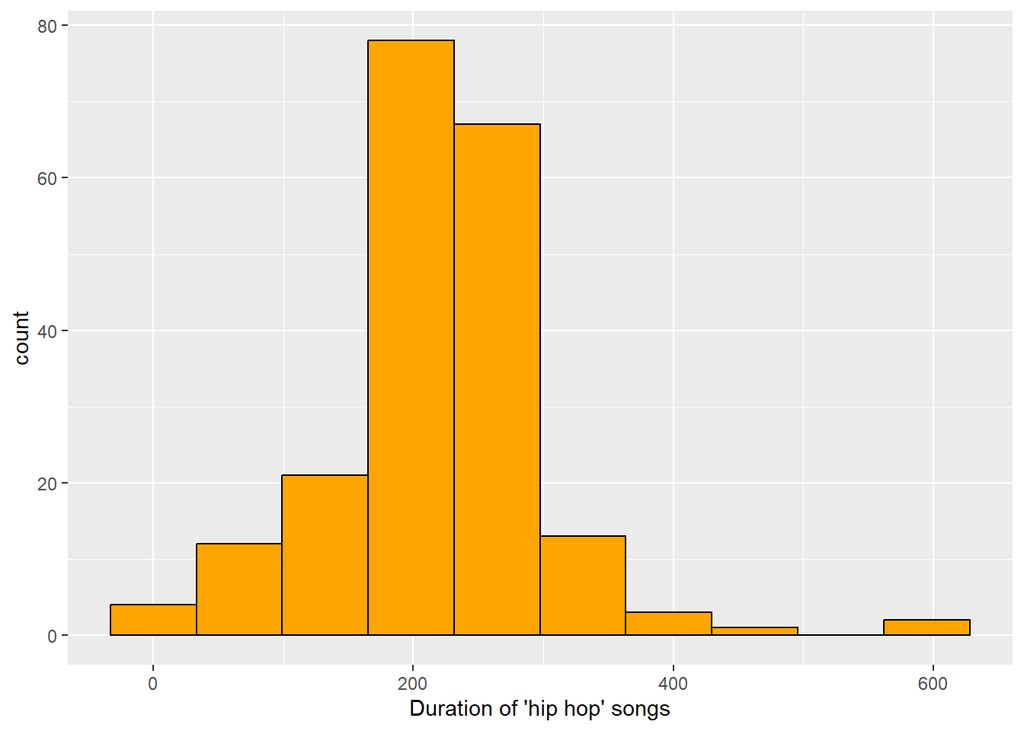

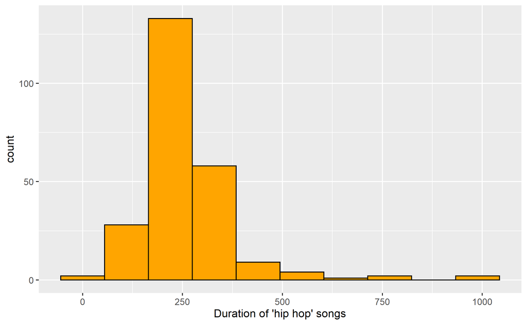

```r
knitr::include_graphics("./ZI/graph1.png")

music %>%
  filter(genre == "hip hop") %>%
  ggplot(aes(duration)) +
  geom_histogram(fill = "orange", color = "black", bins = 10) +
  xlab("Duration of 'hip hop' songs")
```

**(2 boda)** b) `graph2.png`

**RJEŠENJE:**

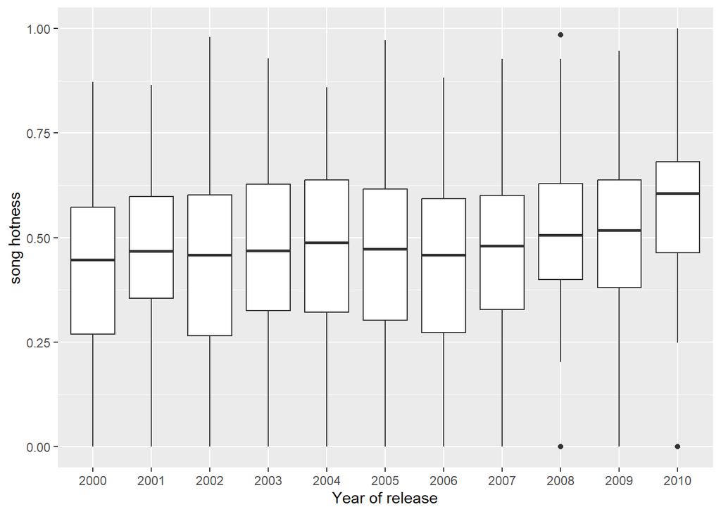

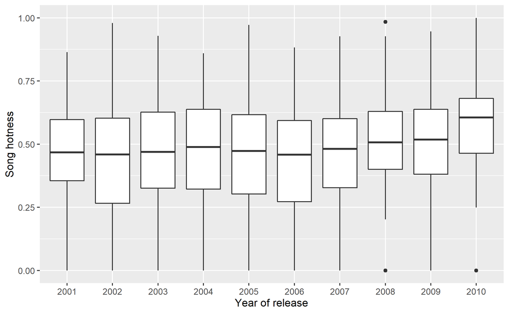

```r
knitr::include_graphics("./ZI/graph2.png")

music %>%
  filter(year >= 2000, year <= 2010) %>%
  group_by(year) %>%
  ggplot(aes(x = as.factor(year), y = song.hotness)) + geom_boxplot() +
  xlab("Year of release") +
  ylab("song hotness")
```

**(2 boda)** c) `graph3.png`

**RJEŠENJE:**

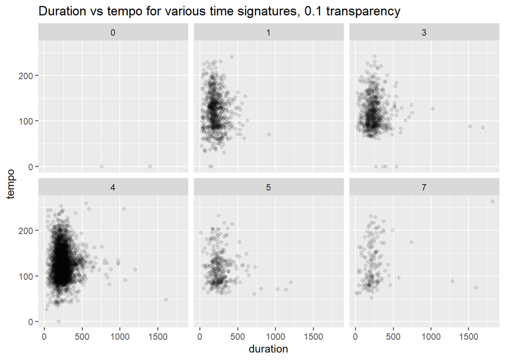

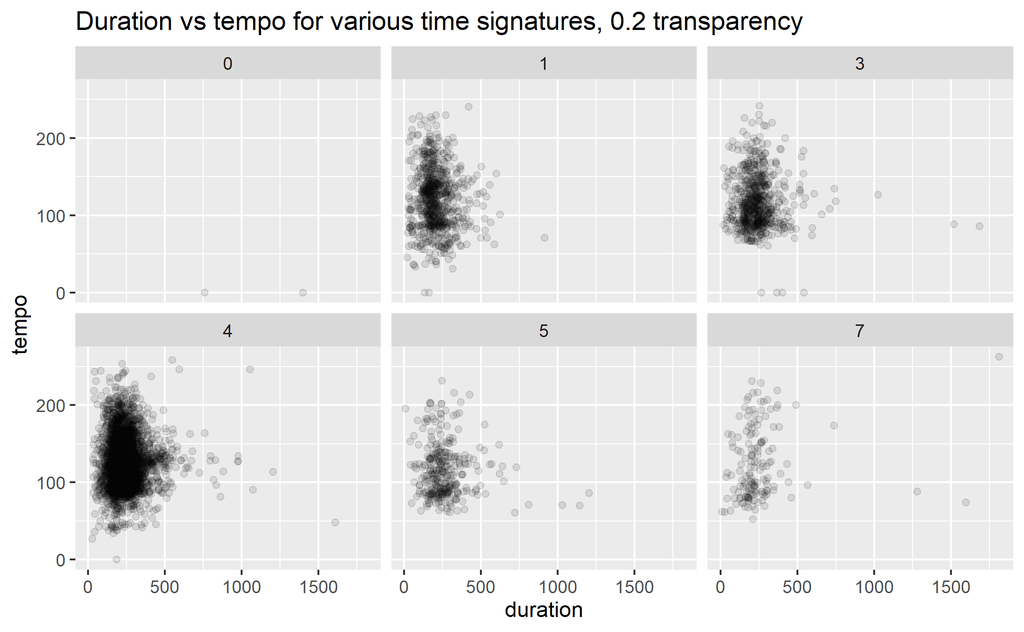

```r
knitr::include_graphics("./ZI/graph3.png")

music %>% ggplot(aes(x = duration, y = tempo)) +
  facet_wrap(time_signature ~ .) + geom_point(alpha = 0.1) +
  ggtitle("Duration vs tempo for various time signatures, 0.1 transparency")
```

## 3. ZADATAK (6 bodova)

Rezultate ovog zadatka ispišite u obliku postotka zaokruženog na dvije decimale, npr. `36.25%`.

**(2 boda)** a) Ako pretpostavimo da se težine mačaka ravnaju po normalnoj razdiobi sa sredinom od 5 kg i standardnom devijacijom 1.5 kg, koja je vjerojatnost da će nasumično odabrana mačka imati između 6 i 7 kg?

**RJEŠENJE:**

```r
str_c(round(pnorm(7, 5, 1.5) - pnorm(6, 5, 1.5), 4) * 100, "%")
```

```
## [1] "16.13%"
```

**(4 boda)**

2. Procijenite vjerojatnost da kod bacanja 5 kockica dobijete “full house” (kockice prikazuju jedan broj tri puta i drugi broj 2 puta). Procjena mora biti izvedena na temelju simulacije 10,000 eksperimenata.

Procijenite vjerojatnost da kod bacanja 5 kockica isti broj dobijete barem 3 puta. Procjena mora biti izvedena na temelju simulacije 10,000 eksperimenata.

Procijenite vjerojatnost da kod bacanja 5 kockica dobijete “full house” (kockice prikazuju jedan broj tri puta i drugi broj 2 puta). Procjena mora biti izvedena na temelju simulacije 10,000 eksperimenata.

Procijenite vjerojatnost da kod bacanja 5 kockica dobijete 5 različitih brojeva. Procjena mora biti izvedena na temelju simulacije 10,000 eksperimenata.

Procijenite vjerojatnost da kod bacanja 5 kockica dobijete samo neparne brojeve. Procjena mora biti izvedena na temelju simulacije 10,000 eksperimenata.

### Rješenje

```r
set.seed(1232)
# neki broj barem 3 puta
replicate(10000, sample(1:6, 5, replace = T)) %>% t %>%
apply(1, function(x) max(table(x)) > 2) %>%
  mean %>% `*`(100) %>% round(2) %>% str_c("%")

# full house
replicate(10000, sample(1:6, 5, replace = T)) %>% t %>%
apply(1, function(x) 3 %in% table(x) && 2 %in% table(x)) %>%
  mean %>% `*`(100) %>% round(2) %>%  str_c("%")

# svi brojevi različiti
replicate(10000, sample(1:6, 5, replace = T)) %>% t %>%
apply(1, function(x) sum(table(x) > 1) == 0 ) %>%
  mean %>% `*`(100) %>% round(2) %>% str_c("%")

# svi neparni
replicate(10000, sample(1:6, 5, replace = T)) %>% t %>%
apply(1, function(x) sum(x %% 2) == 5) %>%
  mean %>% `*`(100) %>% round(2) %>% str_c("%")
```

```
## [1] "20.49%"
## [1] "3.78%"
## [1] "9.12%"
## [1] "3%"
```

## 4. ZADATAK (5 bodova)

Izvršite sljedeći odsječak koji rastavlja podatkovni okvir `music` na dva podokvira.

```r
set.seed(1233)

train_ind <- sample(1:nrow(music), round(0.7 * nrow(music)))
music.train <- music[train_ind, ]
music.test <- music[-train_ind, ]
```

**(2 boda)** a) Korištenjem skupa `music.train` istrenirajte model linearne regresije koji će probati pogoditi *popularnost pjesme* na osnovu trajanja pjesme, tempa i popularnosti umjetnika. Ispišite sažetak modela. Prema dobivenim rezultatima, koju varijablu smatrate najboljim, a koju najlošijim prediktorom popularnosti pjesme?

**RJEŠENJE:**

```r
linearReg <- lm(data = music.train, song.hotness ~ duration + tempo + artist.hotness)
summary(linearReg)
```

```
##
## Call:
## lm(formula = song.hotness ~ duration + tempo + artist.hotness,
##     data = music.train)
##
## Residuals:
##      Min       1Q   Median       3Q      Max
## -0.57960 -0.17321  0.02327  0.15409  0.64968
##
## Coefficients:
##                  Estimate Std. Error t value Pr(>|t|)
## (Intercept)    -1.302e-01  1.809e-02  -7.195  7.5e-13 ***
## duration        3.637e-05  2.892e-05   1.258 0.208637
## tempo           3.777e-04  9.707e-05   3.891 0.000101 ***
## artist.hotness  1.029e+00  2.723e-02  37.784  < 2e-16 ***
## ---
## Signif. codes:  0 '***' 0.001 '**' 0.01 '*' 0.05 '.' 0.1 ' ' 1
##
## Residual standard error: 0.2086 on 3814 degrees of freedom
## Multiple R-squared:  0.2763, Adjusted R-squared:  0.2757
## F-statistic: 485.3 on 3 and 3814 DF,  p-value: < 2.2e-16
```

*KOMENTAR REZULTATA:*

Najbolji prediktor je artist.hotness, a najgori je duration

**(3 boda)** b) Uz pomoć metode `predict` i linearnog modela iz a) zadatka stvorite predikcije korištenjem opservacija iz skupa `music.test` a potom izračunajte reziduale. Provjerite i komentirajte normalnost dobivenih reziduala.

**RJEŠENJE:**

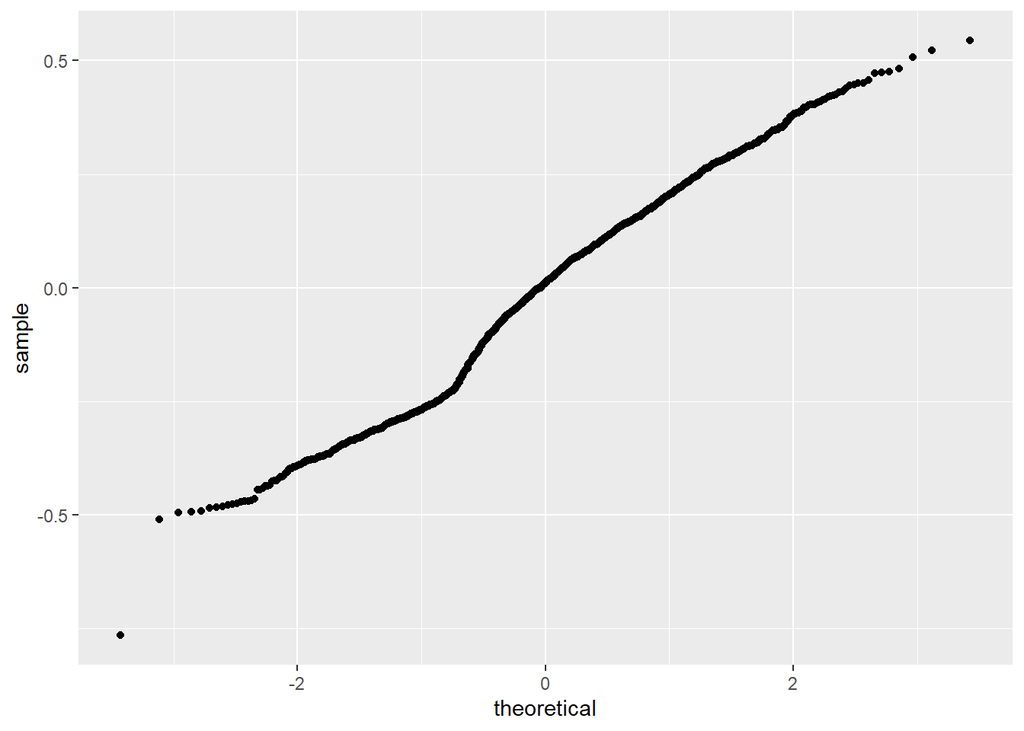

```r
music.test$prediction <- predict(linearReg, music.test)
music.test$residuals <- music.test$song.hotness - music.test$prediction

music.test %>%
  ggplot(aes(sample = residuals)) + geom_qq()
```

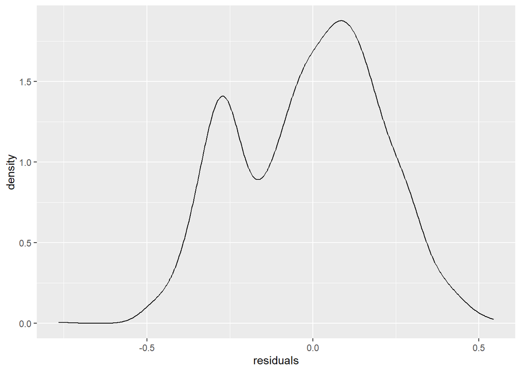

```r
music.test %>%
  ggplot(aes(x = residuals)) + geom_density()
```

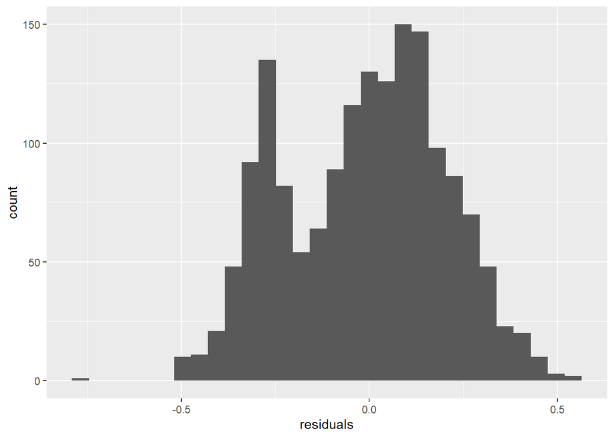

```r
music.test %>%
  ggplot(aes(x = residuals)) + geom_histogram()
```

*KOMENTAR REZULTATA:* Rezultati pokazuju odstupanje od normalnosti. QQ grad prikazuje devijacije od pravca, a na procjeni gustoće možemo vidjeti dva modaliteta